# Factors That Influence Child Mortality Rate

## by Ezra Samuel

## Investigation Overview

The rate of child mortality is a lot higher in some regions than others. For this investigation my intention was to assess factors that influences child mortality rate. The main focus was on: life expectancy, adolescent fertility, sanitation, immunization, income class, and region.

## Dataset Overview

Five pieces of data were gathered online and merged to form a final data. After some wranging, the final data consisted of 2987 rows. The data was originally gathered from 167 countries between 2000 and 2017. The attributes included the parameters named above as well as others like country name, year, and employment rate. During the exploration phase, one data point was removed due to an apparent error.

## Child Mortality Rate Distribution

Child mortality rate ranges from about 1 to a bit less than 300 for every 1000 live births. This is a very wide range between the lower and upper limits. Plotting this values on a logarithmic scale produces a multimodal shape of child mortality rate.

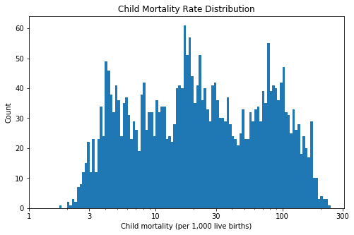

```python
# histogram plot on a log scale
log_data = np.log10(final_data['child_mortality'])
log_binsize = 0.02
bins = 10 ** np.arange(0.2, log_data.max()+log_binsize, log_binsize)

plt.figure(figsize = [8, 5]);
plt.hist(data = final_data, x = 'child_mortality', bins = bins);
plt.xscale('log');
plt.xticks([1, 3, 10, 30, 100, 300], [1, 3, 10, 30, 100, 300]);
plt.xlabel('Child mortality (per 1,000 live births)');
plt.ylabel('Count');
plt.title('Child Mortality Rate Distribution');
```

## Adolescent Fertility Rate Distribution

One of the numeric variables assessed was adolescent fertility rate. Interestingly, the range of values is similar to child mortality rate. Unlike child mortality though, its distribution is unimodal.

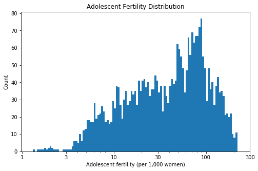

```python
# distribution of adolescent fertility.

log_binsize = 0.02
log_data = np.log10(final_data['adolescent_fertility'])
bins = 10 ** np.arange(0.1, log_data.max()+log_binsize, log_binsize)

plt.figure(figsize = [8, 5]);
plt.hist(data = final_data, x = 'adolescent_fertility', bins = bins);
plt.xscale('log');
plt.xticks([1, 3, 10, 30, 100, 300], [1, 3, 10, 30, 100, 300]);
plt.xlabel('Adolescent fertility (per 1,000 women)');
plt.ylabel('Count');
plt.title('Adolescent Fertility Distribution');
```

## Income Category Plot

The highest data comes from Upper middle income countries and the least from Low income economies.

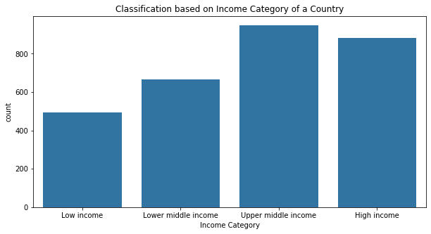

```python
# bar plot of income_group

default_color = sb.color_palette()[0]
plt.figure(figsize = [10, 5])
sb.countplot(data = final_data, x = 'income_group',
             color = default_color);
plt.title('Classification based on Income Category of a Country');
plt.xlabel('Income Category');
```

## A Comparison of Child Mortality with Some Numerical Variables

The plot of child mortality rate with adolescent fertility shows a possitive relationship. As adolescent fertility rate increases, child mortality rate increases. The reverse is the case for life efficiency.

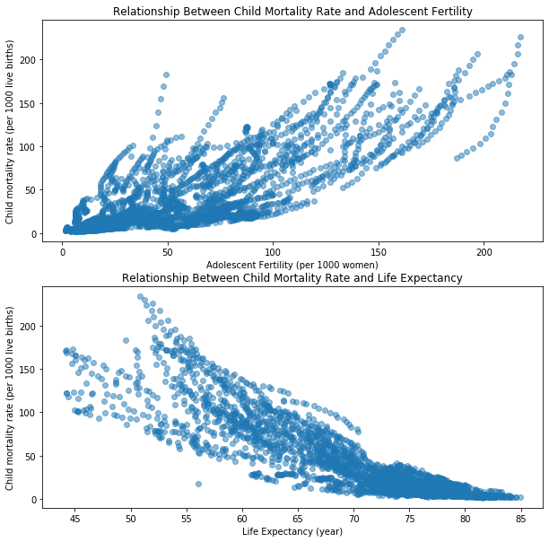

```python
#Plot of child mortality and some numeric variables
fig, ax = plt.subplots(nrows=2, figsize = [10, 10]);

sb.regplot(data = final_data, x = 'adolescent_fertility', y = 'child_mortality', x_jitter = 0.2,
          y_jitter = 0.2, fit_reg = False, scatter_kws = {'alpha': 1/2} , ax = ax[0]);
ax[0].set_title('Relationship Between Child Mortality Rate and Adolescent Fertility');
ax[0].set_xlabel('Adolescent Fertility (per 1000 women)');
ax[0].set_ylabel('Child mortality rate (per 1000 live births)');

sb.regplot(data = final_data, x = 'life_expectancy', y = 'child_mortality', x_jitter = 0.2,
          y_jitter = 0.2, fit_reg = False, scatter_kws = {'alpha': 1/2} , ax = ax[1]);
ax[1].set_title('Relationship Between Child Mortality Rate and Life Expectancy');
ax[1].set_xlabel('Life Expectancy (year)');
ax[1].set_ylabel('Child mortality rate (per 1000 live births)');
```

## A Comparison of Child Mortality with Categorical Variables

A box plot of child mortality rate and the categorical variables reveals an interesting trend. It shows that high mortality rate is associated with low income group and the South Asia and Sub-Saharan African regions. Adolescent fertility rate has a similar trend. Life expectancy, sanitation, and immunization are in the reverse order.

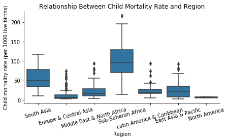

```python
# box plot of child mortality with region

list1 = final_data['year'].tolist()

for i in range(len(list1)):
    var = sample(list1, 3)
    data_sample = final_data[final_data['year'].isin(['{}'.format(var[0]), '{}'.format(var[1]), '{}'.format(var[2])])]
    break
data_sample = data_sample

def boxgrid(x, y, **kwargs):
    default_color = sb.color_palette()[0];
    sb.boxplot(x, y, color = default_color);
    plt.xticks(rotation = 15);


plt.figure(figsize = [10, 8]);
g = sb.PairGrid(data = data_sample, y_vars = 'child_mortality',
                x_vars = 'region', size = 3, aspect = 2);
g.map(boxgrid);

plt.ylabel('Child mortality rate (per 1000 live births)');
plt.title('Relationship Between Child Mortality Rate and Region');
plt.xlabel('Region');
```

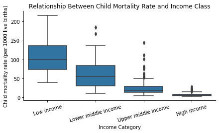

```python
# box plot of child mortality with income group

def boxgrid(x, y, **kwargs):
    default_color = sb.color_palette()[0];
    sb.boxplot(x, y, color = default_color);
    plt.xticks(rotation = 15);

plt.figure(figsize = [10, 8]);
g = sb.PairGrid(data = data_sample, y_vars = 'child_mortality',
                x_vars = 'income_group', size = 3, aspect = 2);
g.map(boxgrid);

plt.ylabel('Child mortality rate (per 1000 live births)');
plt.title('Relationship Between Child Mortality Rate and Income Class');
plt.xlabel('Income Category');
```

## Comparing Child Mortality Rate, Adolescent Fertilty Rate, and Life Expectancy.

The scatterplot shows low life expectancy at the top right of the plot (associated with high child mortality and adolecent fertility rates). High life expectancy is concentrated below 100 of adolescent fertility and below 30 of child mortality rates.

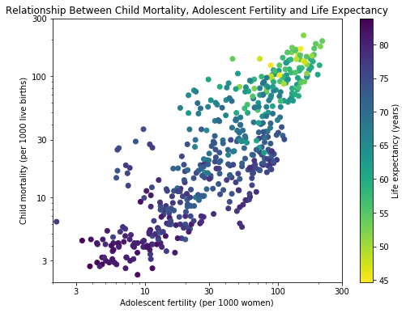

```python
# scatter plot of numerical variables

plt.figure(figsize = [8, 6])

plt.scatter(data = data_sample, x = 'adolescent_fertility', y = 'child_mortality',
           c = 'life_expectancy', cmap = 'viridis_r');
plt.colorbar(label = 'Life expectancy (years)');

ticks = [1, 3, 10, 30, 100, 300];
labels = ticks
plt.xscale('log')
plt.yscale('log')
plt.xticks(ticks, ticks);
plt.yticks(ticks, ticks);
plt.xlim(2, 300);
plt.ylim(2, 300);
plt.xlabel('Adolescent fertility (per 1000 women)');
plt.ylabel('Child mortality (per 1000 live births)');
plt.title('Relationship Between Child Mortality, Adolescent Fertility and Life Expectancy');
```

## Conclusion

High child mortality rate is also associated with low income economies, and low rate with high income economies. Certain regions like North America and Europe & Central Asia has lower child mortality rates than the Sub-Saharan Africa Region.